# Introduction to R

24 October 2018

## Agenda

- Introduction: Data visualisation with `mtcars`
- Basic rules of programming with R
- Workflow
- What is this course about?

## Introduction

## Visualise data with `ggplot2`

- `ggplot2` is a package
  - a *package* consists of functions and other objects which deal with a specific task
  - the task of `ggplot2` is data visualisation
- it implements the grammar of graphics

## Visualise data with `ggplot2`

- `ggplot2` is a package
  - a *package* consists of functions and other objects which deal with a specific task
  - the task of `ggplot2` is data visualisation
- it implements the grammar of graphics

```r
install.packages("ggplot2")
library(ggplot2)
```

## Example dataset: `mtcars`

- data from the 1974 *Motor Trend* US magazine
- variables include:
  - `mpg` Miles/(US) gallon
  - `qsec` 1/4 mile time
  - `vs` V engine or straight engine?

## Grammar of graphics

- the basis of the visualisation is the **data**
- every variable is mapped to an aesthetic **mapping** (e. g. `x`, `y`, `color`)

```r
aes(x = mpg, y = qsec)
```

- a **layer** uses the aesthetic information to build elements of a plot

## Example

Are cars with higher fuel consumption faster?

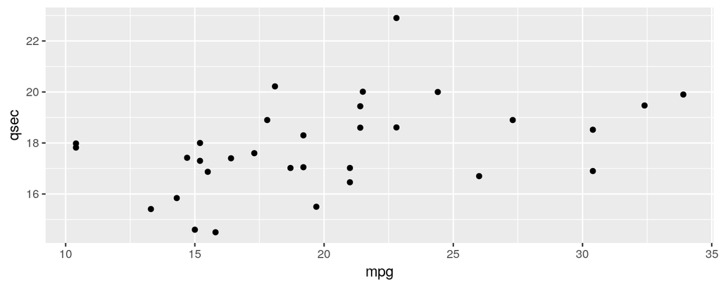

```r
ggplot(data = mtcars, mapping = aes(x = mpg, y = qsec)) +
  geom_point()
```

## Exercise 1: data visualisation

1. Leave out data, mapping and layer in the code above. What happens?
2. Map `vs` to the aesthetic `color`. How does the plot change and why?
3. Look up the different variables of `mtcars` by calling `?mtcars`. Choose two variables which are interesting to you and build their scatterplot.
4. Look up `?geom_bar` and try to build a bar plot answering the question "How is the number of cylinders distributed across the cars?"

## Basic rules of programming with R

## Variables

- Variables store values
- Variables are assigned by `<-`:

```r
x <- 5
x
```

```
## [1] 5
```

## Calculations

```r
5 + 5
```

```
## [1] 10
```

```r
5 * 2
```

```
## [1] 10
```

```r
5 + 2 * (5 / 4)
```

```
## [1] 7.5
```

## Functions

```r
log(x = 2)
```

```
## [1] 0.6931472
```

## Functions

```r
log(x = 2)
```

```
## [1] 0.6931472
```

```r
?log
```

## Functions: default arguments

- Default arguments:
  - allow you to change standard values
  - but only when you need to
- Example: `base` argument of `log`
  - Default value: \(e\)
  - what if you want to compute \(log_2(10)\)?

## Functions: default arguments

- Default arguments:
  - allow you to change standard values
  - but only when you need to
- Example: `base` argument of `log`
  - Default value: \(e\)
  - what if you want to compute \(log_2(10)\)?

```r
log(x = 10, base = 2)
```

```
## [1] 3.321928
```

## Exercise 2

Why do you think that the following code does not work?

```r
2 <- 2
```

```
## Error in 2 <- 2: invalid (do_set) left-hand side to assignment
```

What is the value of x?

```r
x <- 2
x <- 2 * x
```

Look up possible arguments to `geom_point` by calling `?geom_point` and try to make the points in our scatterplot red.

## Workflow

## RStudio environment and scripts

[figure not shown]

## Exercise 3

Create an R script which executes the following lines of code:

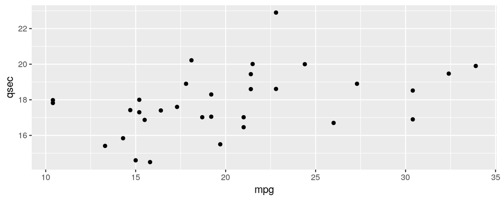

```r
ggplot(mtcars, aes(x = mpg, y = qsec)) +
  geom_point()
```

## Reproducibility

- It is important for other people to understand your analysis
- Understanding your analysis almost always includes reproducing (parts of) it
- You want to make sure you can always recreate your analysis, e. g. with new > values
- You need *scripts* to reproduce your *objects*
- RStudio *projects* are a nice way of gathering scripts with a related purpose

## Getting help

- R documentation: `?<object>` or `??<general_term>`
- StackOverflow
- Error message? Copy and google it.
- Learning resources
- Most importantly: frustration is a normal part of the process.

## Exercise 4

Find out how to build a histogram with `ggplot2`.

## What is this course about?

## Goals

I want to

- teach you the basics of R
- give you an overview over the capabilities of R
- help you learn about the topics you are interested in

## Resources

- "R for Data Science" by Garrett Grolemund and Hadley Wickham (r4ds.had.co.nz)
  - many lectures will be based on this book
  - I will refer you to the appropriate chapters
- DataCamp (datacamp.com)

## The following lectures

- `for` and `while` loops, `if`/`else` conditionals and creating your own functions
- data transformation
- reading in data
- creating reports and books with R

## Further reading

- R4DS, ch. 2-4, 6, 8
- `ggplot2`: https://ggplot2.tidyverse.org/
- [Introduction to the grammar of > graphics](http://vita.had.co.nz/papers/layered-grammar.pdf)
- these slides can be found on github.com/sflippl/r-lectures